# SMART-Seq2 mRNA-Seq of blastocysts from wt M PWD x F FVB OgtT931A-het or OgtT931del-het/wt - embryo filtering and clustering

Sara Formichetti

EMBL Rome  
sara.formichetti@embl.it

January 19th, 2024

# 1 Design of the experiment

Column ‘condition’ (genotype of the embryos) is based on previous in silico establishment of sex (exactly as done below) and - for presence of the mutations - on cDNA genotyping (for T931A mothers) or manual inspection of the reads (for T931del or wt mothers). For female embryos coming from wt or del mothers, if no evidence of the mutation is found among the reads, the mutation can still not be excluded because of the presence of the wt allele; hence, they are annotated as F_U (for “unknown”) even if most likely almost all are WT because of high number of reads for most of them.

| sample | SRR | condition | group_or_time_point | batch | biol_rep | tech_rep | run | library_layout | read_length | sex | genotype | total_reads | uniquely_mapped | multimapped_percent |
| --- | --- | --- | --- | --- | --- | --- | --- | --- | --- | --- | --- | --- | --- | --- |
| 10A | none | F_U | wt_or_T931del_IVF | 1 | 1 | 1 | 1 | PAIRED - | 38 | F | U | 8647872 | 6746370 | 15.37 |
| 10C | none | M_wt | wt_or_T931del_IVF | 1 | 1 | 1 | 1 | PAIRED - | 38 | M | wt | 9357265 | 7359333 | 13.99 |
| 10D | none | F_U | wt_or_T931del_IVF | 1 | 1 | 1 | 1 | PAIRED - | 38 | F | U | 9492803 | 7438949 | 14.31 |
| 10E | none | M_del | wt_or_T931del_IVF | 1 | 1 | 1 | 1 | PAIRED - | 38 | M | del | 9344470 | 7306726 | 14.90 |
| 10F | none | F_U | wt_or_T931del_IVF | 1 | 1 | 1 | 1 | PAIRED - | 38 | F | U | 9283653 | 7213655 | 15.16 |
| 10G | none | F_del | wt_or_T931del_IVF | 1 | 1 | 1 | 1 | PAIRED - | 38 | F | del | 6066712 | 4733168 | 14.84 |
| 10H | none | M_del | wt_or_T931del_IVF | 1 | 1 | 1 | 1 | PAIRED - | 38 | M | del | 6815092 | 5271030 | 14.25 |
| 11A | none | M_del | wt_or_T931del_IVF | 1 | 1 | 1 | 1 | PAIRED - | 38 | M | del | 10278716 | 8022332 | 14.27 |
| 11B | none | M_del | wt_or_T931del_IVF | 1 | 1 | 1 | 1 | PAIRED - | 38 | M | del | 9766863 | 7637324 | 14.62 |
| 11C | none | F_U | wt_or_T931del_IVF | 1 | 1 | 1 | 1 | PAIRED - | 38 | F | U | 10021431 | 7812793 | 15.01 |
| 11D | none | M_del | wt_or_T931del_IVF | 1 | 1 | 1 | 1 | PAIRED - | 38 | M | del | 10216890 | 7985920 | 14.15 |
| 11E | none | M_del | wt_or_T931del_IVF | 1 | 1 | 1 | 1 | PAIRED - | 38 | M | del | 9818187 | 7691176 | 14.03 |
| 11F | none | M_del | wt_or_T931del_IVF | 1 | 1 | 1 | 1 | PAIRED - | 38 | M | del | 9419938 | 7347681 | 14.20 |
| 11G | none | F_del | wt_or_T931del_IVF | 1 | 1 | 1 | 1 | PAIRED - | 38 | F | del | 9873170 | 7750870 | 14.33 |
| 11H | none | F_del | wt_or_T931del_IVF | 1 | 1 | 1 | 1 | PAIRED - | 38 | F | del | 9462785 | 7424196 | 14.76 |
| 12A | none | F_U | wt_or_T931del_IVF | 1 | 1 | 1 | 1 | PAIRED - | 38 | F | U | 8705912 | 6743773 | 15.20 |
| 12B | none | F_U | wt_or_T931del_IVF | 1 | 1 | 1 | 1 | PAIRED - | 38 | F | U | 10111340 | 7885639 | 14.32 |
| 12E | none | M_del | wt_or_T931del_IVF | 1 | 1 | 1 | 1 | PAIRED - | 38 | M | del | 9377374 | 7323020 | 14.55 |
| 12F | none | M_wt | wt_or_T931del_IVF | 1 | 1 | 1 | 1 | PAIRED - | 38 | M | wt | 8564783 | 6703553 | 14.48 |
| 12G | none | F_U | wt_or_T931del_IVF | 1 | 1 | 1 | 1 | PAIRED - | 38 | F | U | 8575519 | 6581476 | 14.05 |
| 12H | none | M_wt | wt_or_T931del_IVF | 1 | 1 | 1 | 1 | PAIRED - | 38 | M | wt | 11266544 | 8737966 | 13.92 |
| 1B | none | F_wt | T931A_IVF | 1 | 1 | 1 | 1 | PAIRED - | 38 | F | wt | 7594013 | 5940297 | 14.41 |
| 1D | none | F_wt | T931A_IVF | 1 | 1 | 1 | 1 | PAIRED - | 38 | F | wt | 7549672 | 5863406 | 14.75 |
| 1F | none | F_T931A | T931A_IVF | 1 | 1 | 1 | 1 | PAIRED - | 38 | F | T931A | 5895985 | 4579384 | 15.02 |
| 1G | none | F_wt | T931A_IVF | 1 | 1 | 1 | 1 | PAIRED - | 38 | F | wt | 8301042 | 6408158 | 14.60 |
| 1H | none | M_wt | T931A_IVF | 1 | 1 | 1 | 1 | PAIRED - | 38 | M | wt | 7989791 | 6195262 | 14.58 |
| 2A | none | M_wt | T931A_IVF | 1 | 1 | 1 | 1 | PAIRED - | 38 | M | wt | 8844141 | 6966254 | 14.68 |
| 2B | none | F_wt | T931A_IVF | 1 | 1 | 1 | 1 | PAIRED - | 38 | F | wt | 8826825 | 6910097 | 14.43 |
| 2C | none | F_wt | T931A_IVF | 1 | 1 | 1 | 1 | PAIRED - | 38 | F | wt | 8679748 | 6917400 | 14.06 |
| 2D | none | F_T931A | T931A_IVF | 1 | 1 | 1 | 1 | PAIRED - | 38 | F | T931A | 8931791 | 6932972 | 15.07 |
| 2F | none | F_T931A | T931A_IVF | 1 | 1 | 1 | 1 | PAIRED - | 38 | F | T931A | 8032021 | 6282827 | 14.50 |
| 2H | none | F_wt | T931A_IVF | 1 | 1 | 1 | 1 | PAIRED - | 38 | F | wt | 8138358 | 6343637 | 14.23 |
| 3A | none | F_wt | T931A_IVF | 1 | 1 | 1 | 1 | PAIRED - | 38 | F | wt | 9382770 | 7273435 | 14.61 |
| 3B | none | F_wt | T931A_IVF | 1 | 1 | 1 | 1 | PAIRED - | 38 | F | wt | 8882107 | 7092574 | 13.09 |
| 3C | none | F_wt | T931A_IVF | 1 | 1 | 1 | 1 | PAIRED - | 38 | F | wt | 9366473 | 7393655 | 14.49 |
| 3D | none | M_T931A | T931A_IVF | 1 | 1 | 1 | 1 | PAIRED - | 38 | M | T931A | 7269322 | 5777355 | 13.81 |
| 3E | none | F_T931A | T931A_IVF | 1 | 1 | 1 | 1 | PAIRED - | 38 | F | T931A | 5847521 | 4682085 | 13.64 |
| 3F | none | M_wt | T931A_IVF | 1 | 1 | 1 | 1 | PAIRED - | 38 | M | wt | 8211044 | 6502547 | 14.02 |
| 4A | none | F_wt | T931A_IVF | 1 | 1 | 1 | 1 | PAIRED - | 38 | F | wt | 5226630 | 4011321 | 14.32 |
| 4C | none | M_wt | T931A_IVF | 1 | 1 | 1 | 1 | PAIRED - | 38 | M | wt | 8708458 | 6871977 | 14.71 |
| 4D | none | M_wt | T931A_IVF | 1 | 1 | 1 | 1 | PAIRED - | 38 | M | wt | 6600434 | 5291729 | 12.90 |
| 4E | none | F_wt | T931A_IVF | 1 | 1 | 1 | 1 | PAIRED - | 38 | F | wt | 7404324 | 5830366 | 14.93 |
| 4F | none | F_wt | T931A_IVF | 1 | 1 | 1 | 1 | PAIRED - | 38 | F | wt | 8221110 | 6425201 | 14.48 |
| 4H | none | M_wt | T931A_IVF | 1 | 1 | 1 | 1 | PAIRED - | 38 | M | wt | 8754173 | 6922766 | 13.91 |
| 5A | none | F_wt | T931A_IVF | 1 | 1 | 1 | 1 | PAIRED - | 38 | F | wt | 6710999 | 5241951 | 13.68 |
| 5B | none | F_wt | T931A_IVF | 1 | 1 | 1 | 1 | PAIRED - | 38 | F | wt | 9570392 | 7440453 | 14.80 |
| 5C | none | F_wt | T931A_IVF | 1 | 1 | 1 | 1 | PAIRED - | 38 | F | wt | 9579810 | 7493207 | 14.61 |
| 5D | none | M_wt | T931A_IVF | 1 | 1 | 1 | 1 | PAIRED - | 38 | M | wt | 7951708 | 6231345 | 14.77 |
| 5F | none | F_wt | T931A_IVF | 1 | 1 | 1 | 1 | PAIRED - | 38 | F | wt | 9345100 | 7391161 | 13.74 |
| 5G | none | M_T931A | T931A_IVF | 1 | 1 | 1 | 1 | PAIRED - | 38 | M | T931A | 8261800 | 6511439 | 14.29 |
| 5H | none | F_wt | T931A_IVF | 1 | 1 | 1 | 1 | PAIRED - | 38 | F | wt | 6846203 | 5317456 | 14.55 |
| 6A | none | F_U | wt_or_T931del_IVF | 1 | 1 | 1 | 1 | PAIRED - | 38 | F | U | 9605576 | 7605368 | 14.24 |
| 6B | none | M_del | wt_or_T931del_IVF | 1 | 1 | 1 | 1 | PAIRED - | 38 | M | del | 11064370 | 8641310 | 14.06 |
| 6D | none | F_U | wt_or_T931del_IVF | 1 | 1 | 1 | 1 | PAIRED - | 38 | F | U | 9458660 | 7303909 | 15.47 |
| 6E | none | F_U | wt_or_T931del_IVF | 1 | 1 | 1 | 1 | PAIRED - | 38 | F | U | 10503143 | 8241361 | 13.95 |
| 9A | none | M_del | wt_or_T931del_IVF | 1 | 1 | 1 | 1 | PAIRED - | 38 | M | del | 7263153 | 5731094 | 14.04 |
| 9B | none | F_U | wt_or_T931del_IVF | 1 | 1 | 1 | 1 | PAIRED - | 38 | F | U | 11079763 | 8711190 | 13.62 |
| 9E | none | F_del | wt_or_T931del_IVF | 1 | 1 | 1 | 1 | PAIRED - | 38 | F | del | 11314111 | 8885760 | 14.56 |
| 9F | none | F_del | wt_or_T931del_IVF | 1 | 1 | 1 | 1 | PAIRED - | 38 | F | del | 7373989 | 5767248 | 14.49 |
| 9G | none | F_U | wt_or_T931del_IVF | 1 | 1 | 1 | 1 | PAIRED - | 38 | F | U | 8918100 | 6995500 | 14.12 |
| 9H | none | F_del | wt_or_T931del_IVF | 1 | 1 | 1 | 1 | PAIRED - | 38 | F | del | 7190585 | 5522675 | 15.00 |

# 2 Quality filtering of embryos

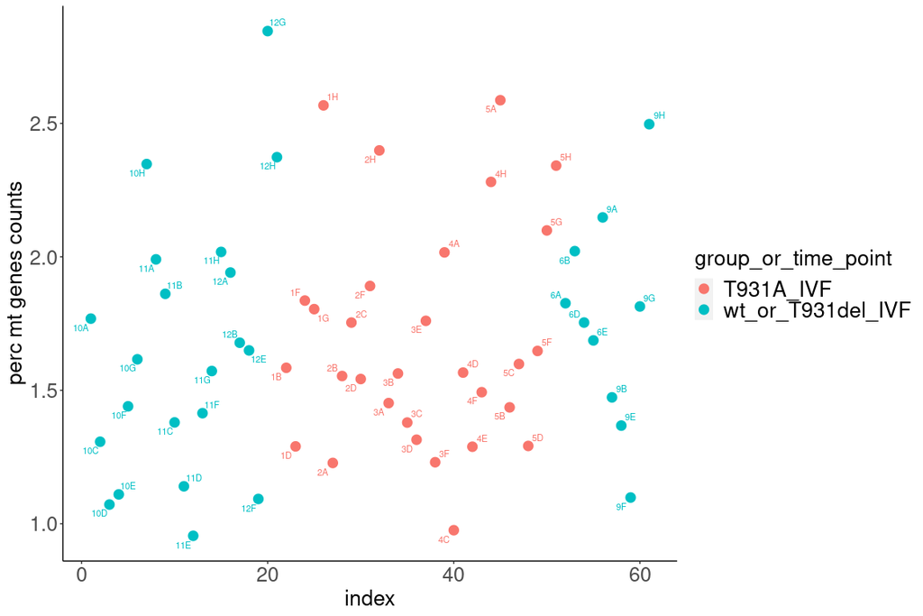

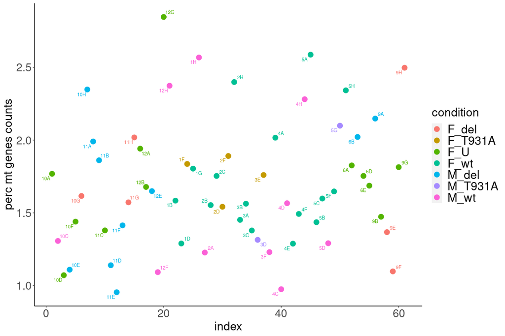

No need to remove any embryo.

# 3 Verifying sex of embryos

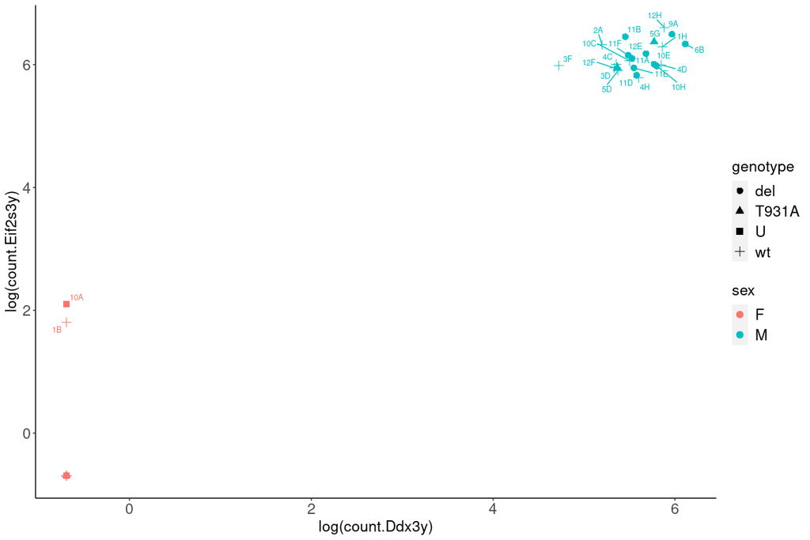

Sex is confirmed for all embryos.

# 4 Embryo genotypes summary

|  | del | T931A | U | wt |
| --- | --- | --- | --- | --- |
| F | 6 | 4 | 12 | 17 |
| M | 10 | 2 | 0 | 10 |

|  | T931A_IVF | wt_or_T931del_IVF |
| --- | --- | --- |
| F_del | 0 | 6 |
| F_T931A | 4 | 0 |
| F_U | 0 | 12 |
| F_wt | 17 | 0 |
| M_del | 0 | 10 |
| M_T931A | 2 | 0 |
| M_wt | 7 | 3 |

# 5 Sample clustering

## 5.1 Heatmap for quality assessment

After applying the log2(n + 1) transformation, I plot heatmaps of normalized counts for top highly expressed genes to check for eventual big sample heterogeneity present in the dataset.

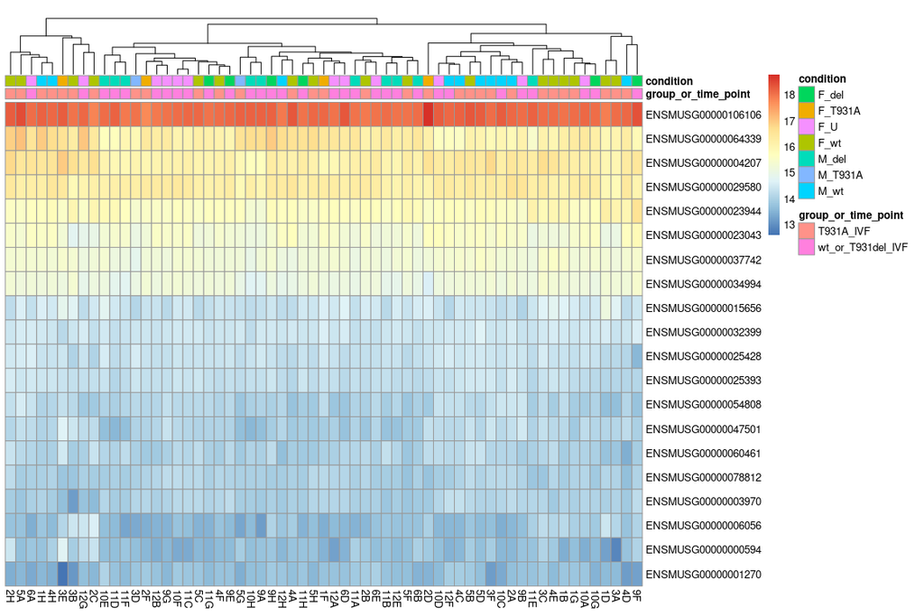

No emerging sample heterogeneity.

## 5.2 PCA

For this PCA:

1. I start with DESeq2-normalized data
2. I keep only genes with DESeq2-normalized mean across samples > 10
3. I apply log2 transformation
4. I perform PCA with package prcomp using the 1000 genes with the highest variance

### 5.2.1 female blastocysts

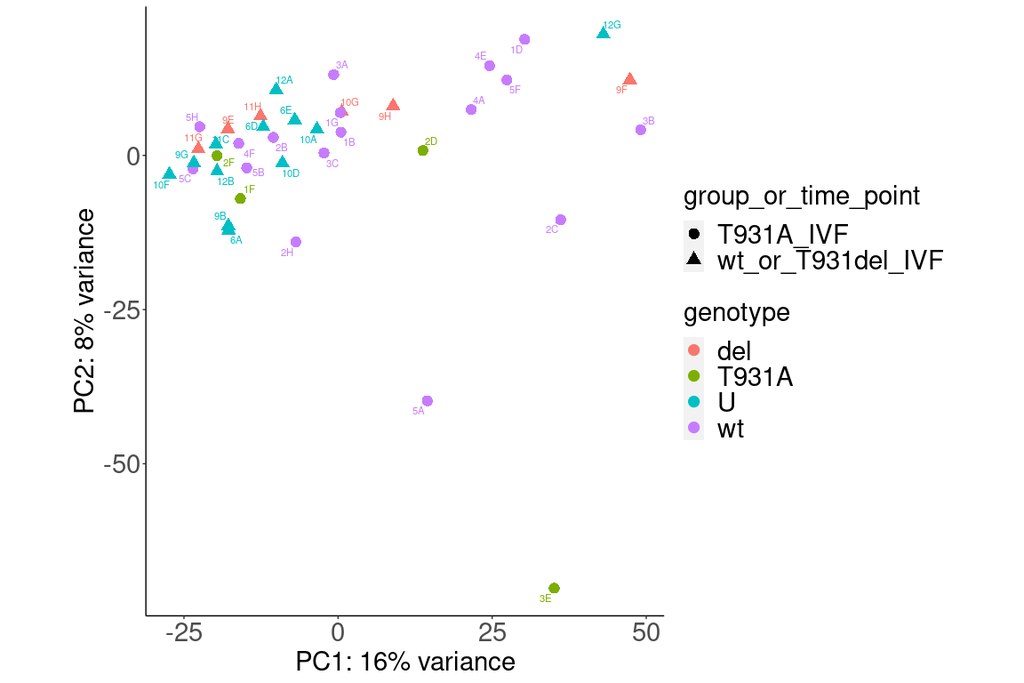

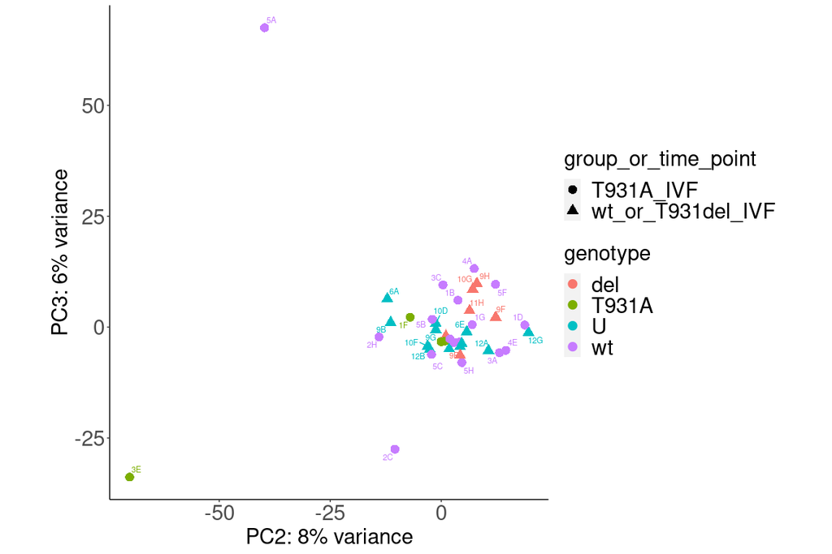

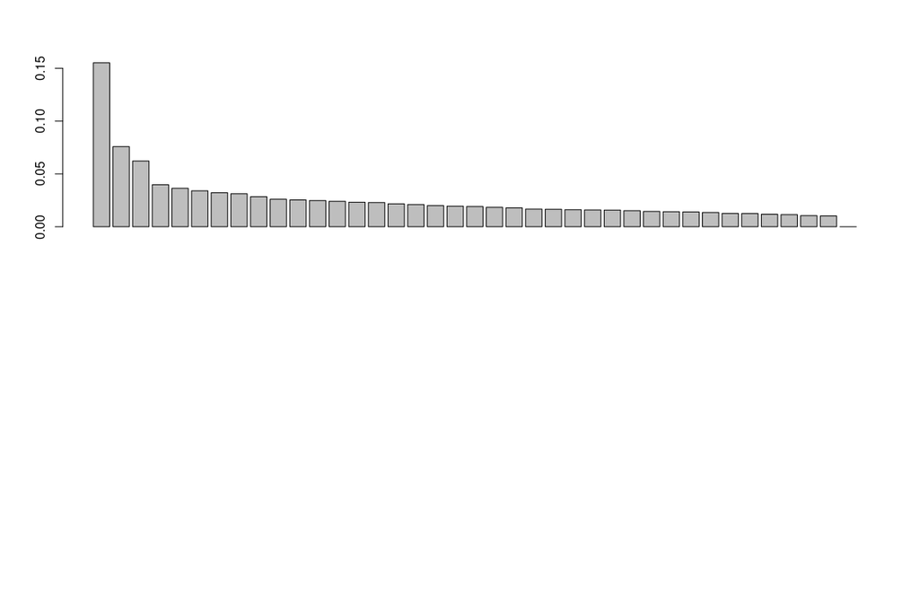

### 5.2.2 male blastocysts

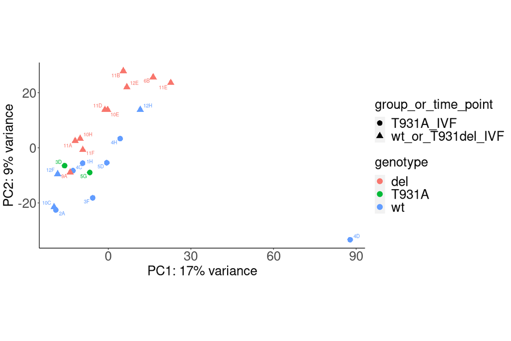

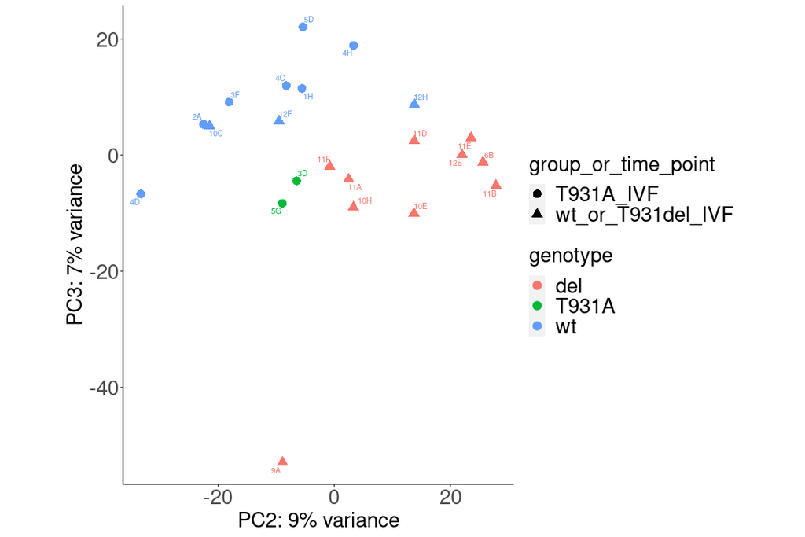

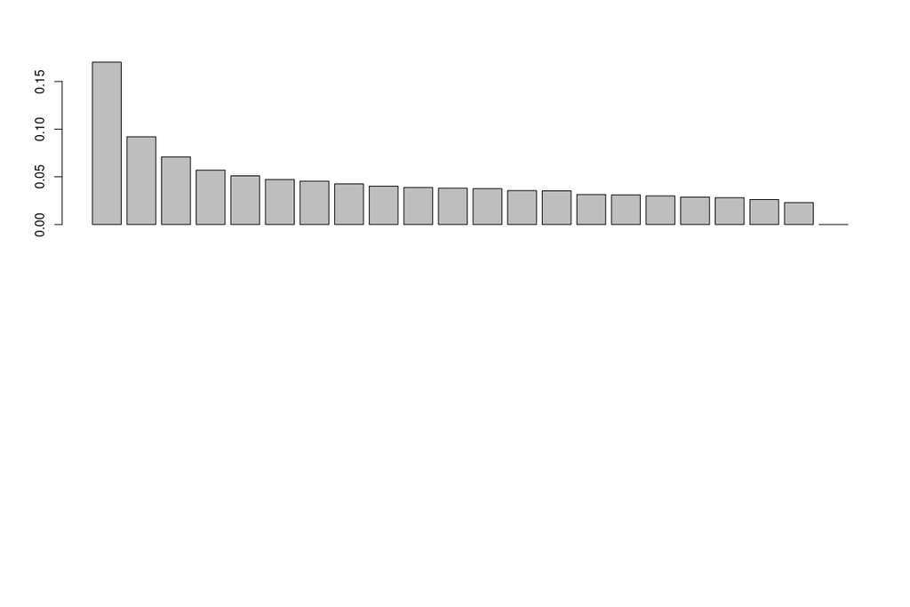

### 5.2.3 Conclusions

- Female embryos do not cluster based on the different Ogt genotypes.
- For male embryos only, some separation between wt and Ogt-mutant ones is evident on PC3.